# Risk Factor Analysis

## Outcome Variable

**Outcome Variable:** stunted

## Predictor Variables

**Intervention Variable:** mhtcm

**Adjustment Set:**

unadjusted

## Stratifying Variables

The analysis was stratified on these variable(s):

- agecat
- studyid
- country

## Data Summary

| agecat | studyid | country | mhtcm | stunted | n_cell | n |
| --- | --- | --- | --- | --- | --- | --- |
| Birth | ki0047075b-MAL-ED | BANGLADESH | >=160 | 0 | 4 | 246 |
| Birth | ki0047075b-MAL-ED | BANGLADESH | >=160 | 1 | 0 | 246 |
| Birth | ki0047075b-MAL-ED | BANGLADESH | <145 | 0 | 41 | 246 |
| Birth | ki0047075b-MAL-ED | BANGLADESH | <145 | 1 | 14 | 246 |
| Birth | ki0047075b-MAL-ED | BANGLADESH | [145-150) | 0 | 70 | 246 |
| Birth | ki0047075b-MAL-ED | BANGLADESH | [145-150) | 1 | 16 | 246 |
| Birth | ki0047075b-MAL-ED | BANGLADESH | [150-155) | 0 | 71 | 246 |
| Birth | ki0047075b-MAL-ED | BANGLADESH | [150-155) | 1 | 9 | 246 |
| Birth | ki0047075b-MAL-ED | BANGLADESH | [155-160) | 0 | 18 | 246 |
| Birth | ki0047075b-MAL-ED | BANGLADESH | [155-160) | 1 | 3 | 246 |
| 6 months | ki0047075b-MAL-ED | BANGLADESH | >=160 | 0 | 4 | 241 |
| 6 months | ki0047075b-MAL-ED | BANGLADESH | >=160 | 1 | 0 | 241 |
| 6 months | ki0047075b-MAL-ED | BANGLADESH | <145 | 0 | 37 | 241 |
| 6 months | ki0047075b-MAL-ED | BANGLADESH | <145 | 1 | 16 | 241 |
| 6 months | ki0047075b-MAL-ED | BANGLADESH | [145-150) | 0 | 67 | 241 |
| 6 months | ki0047075b-MAL-ED | BANGLADESH | [145-150) | 1 | 20 | 241 |
| 6 months | ki0047075b-MAL-ED | BANGLADESH | [150-155) | 0 | 71 | 241 |
| 6 months | ki0047075b-MAL-ED | BANGLADESH | [150-155) | 1 | 6 | 241 |
| 6 months | ki0047075b-MAL-ED | BANGLADESH | [155-160) | 0 | 17 | 241 |
| 6 months | ki0047075b-MAL-ED | BANGLADESH | [155-160) | 1 | 3 | 241 |
| 24 months | ki0047075b-MAL-ED | BANGLADESH | >=160 | 0 | 3 | 212 |
| 24 months | ki0047075b-MAL-ED | BANGLADESH | >=160 | 1 | 1 | 212 |
| 24 months | ki0047075b-MAL-ED | BANGLADESH | <145 | 0 | 14 | 212 |
| 24 months | ki0047075b-MAL-ED | BANGLADESH | <145 | 1 | 30 | 212 |
| 24 months | ki0047075b-MAL-ED | BANGLADESH | [145-150) | 0 | 38 | 212 |
| 24 months | ki0047075b-MAL-ED | BANGLADESH | [145-150) | 1 | 42 | 212 |
| 24 months | ki0047075b-MAL-ED | BANGLADESH | [150-155) | 0 | 44 | 212 |
| 24 months | ki0047075b-MAL-ED | BANGLADESH | [150-155) | 1 | 22 | 212 |
| 24 months | ki0047075b-MAL-ED | BANGLADESH | [155-160) | 0 | 15 | 212 |
| 24 months | ki0047075b-MAL-ED | BANGLADESH | [155-160) | 1 | 3 | 212 |

[output cut: 544 more lines]

The following strata were considered:

- agecat: 24 months, studyid: ki0047075b-MAL-ED, country: BANGLADESH
- agecat: 24 months, studyid: ki0047075b-MAL-ED, country: BRAZIL
- agecat: 24 months, studyid: ki0047075b-MAL-ED, country: INDIA
- agecat: 24 months, studyid: ki0047075b-MAL-ED, country: NEPAL
- agecat: 24 months, studyid: ki0047075b-MAL-ED, country: PERU
- agecat: 24 months, studyid: ki0047075b-MAL-ED, country: SOUTH AFRICA
- agecat: 24 months, studyid: ki0047075b-MAL-ED, country: TANZANIA, UNITED REPUBLIC OF
- agecat: 24 months, studyid: ki1017093-NIH-Birth, country: BANGLADESH
- agecat: 24 months, studyid: ki1017093b-PROVIDE, country: BANGLADESH
- agecat: 24 months, studyid: ki1017093c-NIH-Crypto, country: BANGLADESH
- agecat: 24 months, studyid: ki1066203-TanzaniaChild2, country: TANZANIA, UNITED REPUBLIC OF
- agecat: 24 months, studyid: ki1101329-Keneba, country: GAMBIA
- agecat: 24 months, studyid: ki1119695-PROBIT, country: BELARUS
- agecat: 24 months, studyid: ki1126311-ZVITAMBO, country: ZIMBABWE
- agecat: 24 months, studyid: ki1135781-COHORTS, country: GUATEMALA
- agecat: 24 months, studyid: ki1135781-COHORTS, country: INDIA
- agecat: 24 months, studyid: ki1135781-COHORTS, country: PHILIPPINES
- agecat: 24 months, studyid: ki1148112-LCNI-5, country: MALAWI
- agecat: 24 months, studyid: kiGH5241-JiVitA-3, country: BANGLADESH
- agecat: 6 months, studyid: ki0047075b-MAL-ED, country: BANGLADESH
- agecat: 6 months, studyid: ki0047075b-MAL-ED, country: BRAZIL
- agecat: 6 months, studyid: ki0047075b-MAL-ED, country: INDIA
- agecat: 6 months, studyid: ki0047075b-MAL-ED, country: NEPAL
- agecat: 6 months, studyid: ki0047075b-MAL-ED, country: PERU
- agecat: 6 months, studyid: ki0047075b-MAL-ED, country: SOUTH AFRICA
- agecat: 6 months, studyid: ki0047075b-MAL-ED, country: TANZANIA, UNITED REPUBLIC OF
- agecat: 6 months, studyid: ki1000304b-SAS-CompFeed, country: INDIA
- agecat: 6 months, studyid: ki1000304b-SAS-FoodSuppl, country: INDIA
- agecat: 6 months, studyid: ki1017093-NIH-Birth, country: BANGLADESH
- agecat: 6 months, studyid: ki1017093b-PROVIDE, country: BANGLADESH
- agecat: 6 months, studyid: ki1017093c-NIH-Crypto, country: BANGLADESH
- agecat: 6 months, studyid: ki1066203-TanzaniaChild2, country: TANZANIA, UNITED REPUBLIC OF
- agecat: 6 months, studyid: ki1101329-Keneba, country: GAMBIA
- agecat: 6 months, studyid: ki1112895-Guatemala BSC, country: GUATEMALA
- agecat: 6 months, studyid: ki1119695-PROBIT, country: BELARUS
- agecat: 6 months, studyid: ki1126311-ZVITAMBO, country: ZIMBABWE
- agecat: 6 months, studyid: ki1135781-COHORTS, country: GUATEMALA
- agecat: 6 months, studyid: ki1135781-COHORTS, country: INDIA
- agecat: 6 months, studyid: ki1135781-COHORTS, country: PHILIPPINES
- agecat: 6 months, studyid: ki1148112-LCNI-5, country: MALAWI
- agecat: 6 months, studyid: kiGH5241-JiVitA-3, country: BANGLADESH
- agecat: Birth, studyid: ki0047075b-MAL-ED, country: BANGLADESH
- agecat: Birth, studyid: ki0047075b-MAL-ED, country: BRAZIL
- agecat: Birth, studyid: ki0047075b-MAL-ED, country: INDIA
- agecat: Birth, studyid: ki0047075b-MAL-ED, country: NEPAL
- agecat: Birth, studyid: ki0047075b-MAL-ED, country: PERU
- agecat: Birth, studyid: ki0047075b-MAL-ED, country: SOUTH AFRICA
- agecat: Birth, studyid: ki0047075b-MAL-ED, country: TANZANIA, UNITED REPUBLIC OF
- agecat: Birth, studyid: ki1000304b-SAS-CompFeed, country: INDIA
- agecat: Birth, studyid: ki1017093-NIH-Birth, country: BANGLADESH
- agecat: Birth, studyid: ki1017093c-NIH-Crypto, country: BANGLADESH
- agecat: Birth, studyid: ki1101329-Keneba, country: GAMBIA
- agecat: Birth, studyid: ki1119695-PROBIT, country: BELARUS
- agecat: Birth, studyid: ki1126311-ZVITAMBO, country: ZIMBABWE
- agecat: Birth, studyid: ki1135781-COHORTS, country: GUATEMALA
- agecat: Birth, studyid: ki1135781-COHORTS, country: INDIA
- agecat: Birth, studyid: ki1135781-COHORTS, country: PHILIPPINES
- agecat: Birth, studyid: kiGH5241-JiVitA-3, country: BANGLADESH

### Dropped Strata

Some strata were dropped due to rare outcomes:

- agecat: Birth, studyid: ki0047075b-MAL-ED, country: BANGLADESH
- agecat: 6 months, studyid: ki0047075b-MAL-ED, country: BANGLADESH
- agecat: 24 months, studyid: ki0047075b-MAL-ED, country: BANGLADESH
- agecat: Birth, studyid: ki0047075b-MAL-ED, country: BRAZIL
- agecat: 6 months, studyid: ki0047075b-MAL-ED, country: BRAZIL
- agecat: 24 months, studyid: ki0047075b-MAL-ED, country: BRAZIL
- agecat: Birth, studyid: ki0047075b-MAL-ED, country: INDIA
- agecat: 6 months, studyid: ki0047075b-MAL-ED, country: INDIA
- agecat: 24 months, studyid: ki0047075b-MAL-ED, country: INDIA
- agecat: 6 months, studyid: ki0047075b-MAL-ED, country: NEPAL
- agecat: 24 months, studyid: ki0047075b-MAL-ED, country: NEPAL
- agecat: Birth, studyid: ki0047075b-MAL-ED, country: NEPAL
- agecat: Birth, studyid: ki0047075b-MAL-ED, country: PERU
- agecat: 6 months, studyid: ki0047075b-MAL-ED, country: PERU
- agecat: 24 months, studyid: ki0047075b-MAL-ED, country: PERU
- agecat: Birth, studyid: ki0047075b-MAL-ED, country: SOUTH AFRICA
- agecat: 6 months, studyid: ki0047075b-MAL-ED, country: SOUTH AFRICA
- agecat: 24 months, studyid: ki0047075b-MAL-ED, country: SOUTH AFRICA
- agecat: Birth, studyid: ki0047075b-MAL-ED, country: TANZANIA, UNITED REPUBLIC OF
- agecat: 6 months, studyid: ki0047075b-MAL-ED, country: TANZANIA, UNITED REPUBLIC OF
- agecat: 24 months, studyid: ki0047075b-MAL-ED, country: TANZANIA, UNITED REPUBLIC OF
- agecat: Birth, studyid: ki1000304b-SAS-CompFeed, country: INDIA
- agecat: 6 months, studyid: ki1000304b-SAS-FoodSuppl, country: INDIA
- agecat: 6 months, studyid: ki1017093-NIH-Birth, country: BANGLADESH
- agecat: 24 months, studyid: ki1017093-NIH-Birth, country: BANGLADESH
- agecat: Birth, studyid: ki1017093-NIH-Birth, country: BANGLADESH
- agecat: 6 months, studyid: ki1017093b-PROVIDE, country: BANGLADESH
- agecat: Birth, studyid: ki1017093c-NIH-Crypto, country: BANGLADESH
- agecat: 6 months, studyid: ki1017093c-NIH-Crypto, country: BANGLADESH
- agecat: 24 months, studyid: ki1017093c-NIH-Crypto, country: BANGLADESH
- agecat: 24 months, studyid: ki1066203-TanzaniaChild2, country: TANZANIA, UNITED REPUBLIC OF
- agecat: Birth, studyid: ki1101329-Keneba, country: GAMBIA
- agecat: 6 months, studyid: ki1101329-Keneba, country: GAMBIA
- agecat: 24 months, studyid: ki1101329-Keneba, country: GAMBIA
- agecat: 6 months, studyid: ki1112895-Guatemala BSC, country: GUATEMALA
- agecat: Birth, studyid: ki1119695-PROBIT, country: BELARUS
- agecat: 6 months, studyid: ki1119695-PROBIT, country: BELARUS
- agecat: 24 months, studyid: ki1119695-PROBIT, country: BELARUS
- agecat: 24 months, studyid: ki1126311-ZVITAMBO, country: ZIMBABWE
- agecat: Birth, studyid: ki1135781-COHORTS, country: GUATEMALA
- agecat: 6 months, studyid: ki1135781-COHORTS, country: GUATEMALA
- agecat: Birth, studyid: ki1135781-COHORTS, country: PHILIPPINES
- agecat: 6 months, studyid: ki1148112-LCNI-5, country: MALAWI
- agecat: 24 months, studyid: ki1148112-LCNI-5, country: MALAWI

## Methods Detail

We’re interested in the causal parameters $E[Y_a]$ for all values of $a \in \mathcal{A}$. These parameters represent the mean outcome if, possibly contrary to fact, we intervened to set all units to have $A=a$. Under the randomization and positivity assumptions, these are identified by the statistical parameters $\psi_a=E_W[E_{Y|A,W}(Y|A=a,W)]$. In addition, we’re interested in the mean of $Y$, $E[Y]$ under no intervention (the observed mean). We will estimate these parameters by using SuperLearner to fit the relevant likelihood factors – $E_{Y|A,W}(Y|A=a,W)$ and $p(A=a|W)$, and then updating our likelihood fit using a joint TMLE.

For unadjusted analyses ($W=\{\}$), initial likelihoods were estimated using Lrnr_glm to estimate the simple $E(Y|A)$ and Lrnr_mean to estimate $p(A)$. For adjusted analyses, a small library containing Lrnr_glmnet, Lrnr_xgboost, and Lrnr_mean was used.

Having estimated these parameters, we will then use the delta method to estimate relative risks and attributable risks relative to a prespecified baseline level of $A$.

# Results Detail

## Results Plots

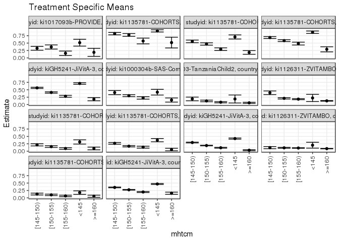

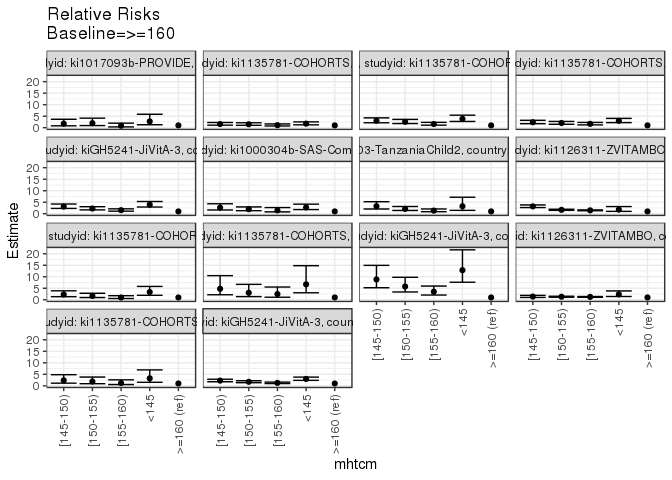

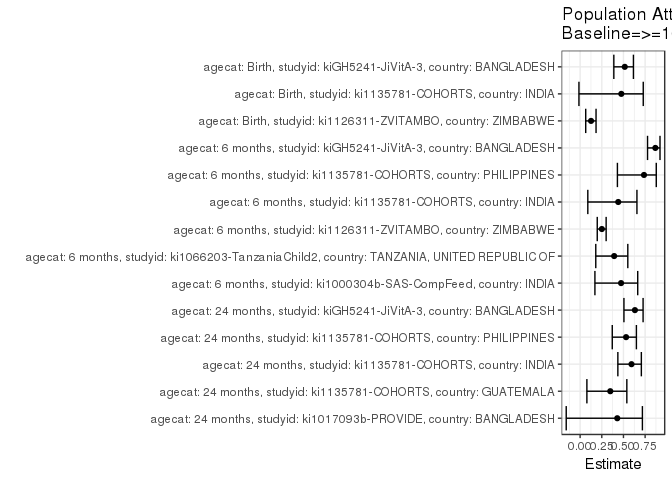

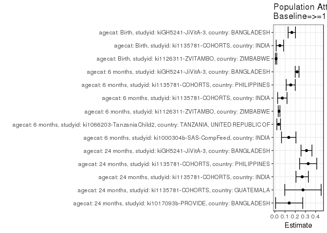

## Results Table

### Parameter: TSM

| agecat | studyid | country | intervention_level | baseline_level | estimate | ci_lower | ci_upper |
| --- | --- | --- | --- | --- | --- | --- | --- |
| Birth | ki1126311-ZVITAMBO | ZIMBABWE | >=160 | NA | 0.0865979 | 0.0786823 | 0.0945135 |
| Birth | ki1126311-ZVITAMBO | ZIMBABWE | <145 | NA | 0.2031250 | 0.1045521 | 0.3016979 |
| Birth | ki1126311-ZVITAMBO | ZIMBABWE | [145-150) | NA | 0.1205212 | 0.0841007 | 0.1569417 |
| Birth | ki1126311-ZVITAMBO | ZIMBABWE | [150-155) | NA | 0.1136935 | 0.0980994 | 0.1292875 |
| Birth | ki1126311-ZVITAMBO | ZIMBABWE | [155-160) | NA | 0.1075683 | 0.0962006 | 0.1189360 |
| Birth | ki1135781-COHORTS | INDIA | >=160 | NA | 0.0544218 | 0.0177403 | 0.0911033 |
| Birth | ki1135781-COHORTS | INDIA | <145 | NA | 0.1772152 | 0.1176578 | 0.2367726 |
| Birth | ki1135781-COHORTS | INDIA | [145-150) | NA | 0.1286920 | 0.0985381 | 0.1588458 |
| Birth | ki1135781-COHORTS | INDIA | [150-155) | NA | 0.1013072 | 0.0773949 | 0.1252194 |
| Birth | ki1135781-COHORTS | INDIA | [155-160) | NA | 0.0652742 | 0.0405294 | 0.0900189 |
| Birth | kiGH5241-JiVitA-3 | BANGLADESH | >=160 | NA | 0.1567010 | 0.1199830 | 0.1934190 |
| Birth | kiGH5241-JiVitA-3 | BANGLADESH | <145 | NA | 0.4691781 | 0.4520324 | 0.4863237 |
| Birth | kiGH5241-JiVitA-3 | BANGLADESH | [145-150) | NA | 0.3524761 | 0.3397615 | 0.3651907 |
| Birth | kiGH5241-JiVitA-3 | BANGLADESH | [150-155) | NA | 0.2722464 | 0.2598314 | 0.2846614 |
| Birth | kiGH5241-JiVitA-3 | BANGLADESH | [155-160) | NA | 0.1983437 | 0.1804860 | 0.2162014 |
| 6 months | ki1000304b-SAS-CompFeed | INDIA | >=160 | NA | 0.1520468 | 0.0830256 | 0.2210680 |
| 6 months | ki1000304b-SAS-CompFeed | INDIA | <145 | NA | 0.4174757 | 0.3212831 | 0.5136684 |
| 6 months | ki1000304b-SAS-CompFeed | INDIA | [145-150) | NA | 0.4042553 | 0.3335878 | 0.4749228 |
| 6 months | ki1000304b-SAS-CompFeed | INDIA | [150-155) | NA | 0.3000000 | 0.2680835 | 0.3319165 |
| 6 months | ki1000304b-SAS-CompFeed | INDIA | [155-160) | NA | 0.2241888 | 0.1831224 | 0.2652552 |
| 6 months | ki1066203-TanzaniaChild2 | TANZANIA, UNITED REPUBLIC OF | >=160 | NA | 0.0577933 | 0.0386485 | 0.0769381 |
| 6 months | ki1066203-TanzaniaChild2 | TANZANIA, UNITED REPUBLIC OF | <145 | NA | 0.1875000 | 0.0522323 | 0.3227677 |
| 6 months | ki1066203-TanzaniaChild2 | TANZANIA, UNITED REPUBLIC OF | [145-150) | NA | 0.1895425 | 0.1274227 | 0.2516622 |
| 6 months | ki1066203-TanzaniaChild2 | TANZANIA, UNITED REPUBLIC OF | [150-155) | NA | 0.1221239 | 0.0951186 | 0.1491292 |
| 6 months | ki1066203-TanzaniaChild2 | TANZANIA, UNITED REPUBLIC OF | [155-160) | NA | 0.0785185 | 0.0582214 | 0.0988156 |
| 6 months | ki1126311-ZVITAMBO | ZIMBABWE | >=160 | NA | 0.1240814 | 0.1132175 | 0.1349453 |
| 6 months | ki1126311-ZVITAMBO | ZIMBABWE | <145 | NA | 0.2222222 | 0.1007453 | 0.3436992 |
| 6 months | ki1126311-ZVITAMBO | ZIMBABWE | [145-150) | NA | 0.3975410 | 0.3361311 | 0.4589509 |
| 6 months | ki1126311-ZVITAMBO | ZIMBABWE | [150-155) | NA | 0.2094421 | 0.1860744 | 0.2328097 |
| 6 months | ki1126311-ZVITAMBO | ZIMBABWE | [155-160) | NA | 0.1827554 | 0.1663573 | 0.1991534 |
| 6 months | ki1135781-COHORTS | INDIA | >=160 | NA | 0.0933333 | 0.0467679 | 0.1398988 |
| 6 months | ki1135781-COHORTS | INDIA | <145 | NA | 0.3128834 | 0.2416834 | 0.3840835 |
| 6 months | ki1135781-COHORTS | INDIA | [145-150) | NA | 0.2141414 | 0.1779932 | 0.2502897 |
| 6 months | ki1135781-COHORTS | INDIA | [150-155) | NA | 0.1548387 | 0.1263560 | 0.1833214 |
| 6 months | ki1135781-COHORTS | INDIA | [155-160) | NA | 0.0920716 | 0.0634056 | 0.1207377 |
| 6 months | ki1135781-COHORTS | PHILIPPINES | >=160 | NA | 0.0555556 | 0.0123471 | 0.0987640 |
| 6 months | ki1135781-COHORTS | PHILIPPINES | <145 | NA | 0.3728223 | 0.3168680 | 0.4287766 |
| 6 months | ki1135781-COHORTS | PHILIPPINES | [145-150) | NA | 0.2658080 | 0.2361741 | 0.2954418 |
| 6 months | ki1135781-COHORTS | PHILIPPINES | [150-155) | NA | 0.1689861 | 0.1458250 | 0.1921472 |
| 6 months | ki1135781-COHORTS | PHILIPPINES | [155-160) | NA | 0.1368653 | 0.1052087 | 0.1685220 |
| 6 months | kiGH5241-JiVitA-3 | BANGLADESH | >=160 | NA | 0.0331859 | 0.0158784 | 0.0504934 |
| 6 months | kiGH5241-JiVitA-3 | BANGLADESH | <145 | NA | 0.4267739 | 0.4063416 | 0.4472061 |
| 6 months | kiGH5241-JiVitA-3 | BANGLADESH | [145-150) | NA | 0.2934686 | 0.2802441 | 0.3066931 |
| 6 months | kiGH5241-JiVitA-3 | BANGLADESH | [150-155) | NA | 0.1912471 | 0.1803975 | 0.2020967 |
| 6 months | kiGH5241-JiVitA-3 | BANGLADESH | [155-160) | NA | 0.1159420 | 0.1011207 | 0.1307634 |
| 24 months | ki1017093b-PROVIDE | BANGLADESH | >=160 | NA | 0.1875000 | 0.0521486 | 0.3228514 |
| 24 months | ki1017093b-PROVIDE | BANGLADESH | <145 | NA | 0.5138889 | 0.3983411 | 0.6294367 |
| 24 months | ki1017093b-PROVIDE | BANGLADESH | [145-150) | NA | 0.3250000 | 0.2600313 | 0.3899687 |
| 24 months | ki1017093b-PROVIDE | BANGLADESH | [150-155) | NA | 0.3681319 | 0.2980017 | 0.4382620 |
| 24 months | ki1017093b-PROVIDE | BANGLADESH | [155-160) | NA | 0.1555556 | 0.0806123 | 0.2304988 |
| 24 months | ki1135781-COHORTS | GUATEMALA | >=160 | NA | 0.5172414 | 0.3352802 | 0.6992025 |
| 24 months | ki1135781-COHORTS | GUATEMALA | <145 | NA | 0.9124424 | 0.8748166 | 0.9500682 |
| 24 months | ki1135781-COHORTS | GUATEMALA | [145-150) | NA | 0.8189415 | 0.7790891 | 0.8587939 |
| 24 months | ki1135781-COHORTS | GUATEMALA | [150-155) | NA | 0.7755102 | 0.7277920 | 0.8232284 |
| 24 months | ki1135781-COHORTS | GUATEMALA | [155-160) | NA | 0.5714286 | 0.4734016 | 0.6694555 |
| 24 months | ki1135781-COHORTS | INDIA | >=160 | NA | 0.1842105 | 0.1225664 | 0.2458547 |
| 24 months | ki1135781-COHORTS | INDIA | <145 | NA | 0.7073171 | 0.6376622 | 0.7769719 |
| 24 months | ki1135781-COHORTS | INDIA | [145-150) | NA | 0.5576132 | 0.5134442 | 0.6017821 |
| 24 months | ki1135781-COHORTS | INDIA | [150-155) | NA | 0.4700162 | 0.4306238 | 0.5094086 |
| 24 months | ki1135781-COHORTS | INDIA | [155-160) | NA | 0.2950000 | 0.2502963 | 0.3397037 |
| 24 months | ki1135781-COHORTS | PHILIPPINES | >=160 | NA | 0.2897196 | 0.2037492 | 0.3756900 |
| 24 months | ki1135781-COHORTS | PHILIPPINES | <145 | NA | 0.8671875 | 0.8256067 | 0.9087683 |
| 24 months | ki1135781-COHORTS | PHILIPPINES | [145-150) | NA | 0.6873385 | 0.6546730 | 0.7200040 |
| 24 months | ki1135781-COHORTS | PHILIPPINES | [150-155) | NA | 0.5834254 | 0.5512998 | 0.6155510 |
| 24 months | ki1135781-COHORTS | PHILIPPINES | [155-160) | NA | 0.4838710 | 0.4350700 | 0.5326719 |
| 24 months | kiGH5241-JiVitA-3 | BANGLADESH | >=160 | NA | 0.1806167 | 0.1266738 | 0.2345596 |
| 24 months | kiGH5241-JiVitA-3 | BANGLADESH | <145 | NA | 0.7122546 | 0.6852705 | 0.7392387 |
| 24 months | kiGH5241-JiVitA-3 | BANGLADESH | [145-150) | NA | 0.5632458 | 0.5435082 | 0.5829835 |
| 24 months | kiGH5241-JiVitA-3 | BANGLADESH | [150-155) | NA | 0.4083478 | 0.3865850 | 0.4301106 |
| 24 months | kiGH5241-JiVitA-3 | BANGLADESH | [155-160) | NA | 0.2796688 | 0.2483118 | 0.3110259 |

### Parameter: E(Y)

| agecat | studyid | country | intervention_level | baseline_level | estimate | ci_lower | ci_upper |
| --- | --- | --- | --- | --- | --- | --- | --- |
| Birth | ki1126311-ZVITAMBO | ZIMBABWE | NA | NA | 0.0991000 | 0.0931434 | 0.1050567 |
| Birth | ki1135781-COHORTS | INDIA | NA | NA | 0.1037204 | 0.0895283 | 0.1179125 |
| Birth | kiGH5241-JiVitA-3 | BANGLADESH | NA | NA | 0.3230958 | 0.3154261 | 0.3307655 |
| 6 months | ki1000304b-SAS-CompFeed | INDIA | NA | NA | 0.2882736 | 0.2624662 | 0.3140810 |
| 6 months | ki1066203-TanzaniaChild2 | TANZANIA, UNITED REPUBLIC OF | NA | NA | 0.0951904 | 0.0823123 | 0.1080685 |
| 6 months | ki1126311-ZVITAMBO | ZIMBABWE | NA | NA | 0.1655908 | 0.1569598 | 0.1742218 |
| 6 months | ki1135781-COHORTS | INDIA | NA | NA | 0.1665750 | 0.1494477 | 0.1837024 |
| 6 months | ki1135781-COHORTS | PHILIPPINES | NA | NA | 0.2112260 | 0.1958496 | 0.2266024 |
| 6 months | kiGH5241-JiVitA-3 | BANGLADESH | NA | NA | 0.2515363 | 0.2434210 | 0.2596516 |
| 24 months | ki1017093b-PROVIDE | BANGLADESH | NA | NA | 0.3281250 | 0.2897474 | 0.3665026 |
| 24 months | ki1135781-COHORTS | GUATEMALA | NA | NA | 0.7933801 | 0.7682355 | 0.8185248 |
| 24 months | ki1135781-COHORTS | INDIA | NA | NA | 0.4524464 | 0.4295668 | 0.4753260 |
| 24 months | ki1135781-COHORTS | PHILIPPINES | NA | NA | 0.6167689 | 0.5974942 | 0.6360437 |
| 24 months | kiGH5241-JiVitA-3 | BANGLADESH | NA | NA | 0.4911036 | 0.4779420 | 0.5042652 |

### Parameter: RR

| agecat | studyid | country | intervention_level | baseline_level | estimate | ci_lower | ci_upper |
| --- | --- | --- | --- | --- | --- | --- | --- |
| Birth | ki1126311-ZVITAMBO | ZIMBABWE | >=160 | >=160 | 1.0000000 | 1.0000000 | 1.000000 |
| Birth | ki1126311-ZVITAMBO | ZIMBABWE | <145 | >=160 | 2.3456101 | 1.4315106 | 3.843413 |
| Birth | ki1126311-ZVITAMBO | ZIMBABWE | [145-150) | >=160 | 1.3917326 | 1.0149467 | 1.908395 |
| Birth | ki1126311-ZVITAMBO | ZIMBABWE | [150-155) | >=160 | 1.3128888 | 1.1133838 | 1.548143 |
| Birth | ki1126311-ZVITAMBO | ZIMBABWE | [155-160) | >=160 | 1.2421580 | 1.0801768 | 1.428430 |
| Birth | ki1135781-COHORTS | INDIA | >=160 | >=160 | 1.0000000 | 1.0000000 | 1.000000 |
| Birth | ki1135781-COHORTS | INDIA | <145 | >=160 | 3.2563291 | 1.5333263 | 6.915475 |
| Birth | ki1135781-COHORTS | INDIA | [145-150) | >=160 | 2.3647152 | 1.1584349 | 4.827097 |
| Birth | ki1135781-COHORTS | INDIA | [150-155) | >=160 | 1.8615196 | 0.9114091 | 3.802085 |
| Birth | ki1135781-COHORTS | INDIA | [155-160) | >=160 | 1.1994125 | 0.5535060 | 2.599051 |
| Birth | kiGH5241-JiVitA-3 | BANGLADESH | >=160 | >=160 | 1.0000000 | 1.0000000 | 1.000000 |
| Birth | kiGH5241-JiVitA-3 | BANGLADESH | <145 | >=160 | 2.9940970 | 2.3637213 | 3.792586 |
| Birth | kiGH5241-JiVitA-3 | BANGLADESH | [145-150) | >=160 | 2.2493543 | 1.7756512 | 2.849430 |
| Birth | kiGH5241-JiVitA-3 | BANGLADESH | [150-155) | >=160 | 1.7373620 | 1.3707222 | 2.202071 |
| Birth | kiGH5241-JiVitA-3 | BANGLADESH | [155-160) | >=160 | 1.2657459 | 0.9895522 | 1.619028 |
| 6 months | ki1000304b-SAS-CompFeed | INDIA | >=160 | >=160 | 1.0000000 | 1.0000000 | 1.000000 |
| 6 months | ki1000304b-SAS-CompFeed | INDIA | <145 | >=160 | 2.7457058 | 1.8117183 | 4.161188 |
| 6 months | ki1000304b-SAS-CompFeed | INDIA | [145-150) | >=160 | 2.6587561 | 1.6327323 | 4.329543 |
| 6 months | ki1000304b-SAS-CompFeed | INDIA | [150-155) | >=160 | 1.9730769 | 1.3155667 | 2.959206 |
| 6 months | ki1000304b-SAS-CompFeed | INDIA | [155-160) | >=160 | 1.4744724 | 0.8109171 | 2.681000 |
| 6 months | ki1066203-TanzaniaChild2 | TANZANIA, UNITED REPUBLIC OF | >=160 | >=160 | 1.0000000 | 1.0000000 | 1.000000 |
| 6 months | ki1066203-TanzaniaChild2 | TANZANIA, UNITED REPUBLIC OF | <145 | >=160 | 3.2443182 | 1.4667630 | 7.176075 |
| 6 months | ki1066203-TanzaniaChild2 | TANZANIA, UNITED REPUBLIC OF | [145-150) | >=160 | 3.2796593 | 2.0580332 | 5.226430 |
| 6 months | ki1066203-TanzaniaChild2 | TANZANIA, UNITED REPUBLIC OF | [150-155) | >=160 | 2.1131134 | 1.4188882 | 3.147005 |
| 6 months | ki1066203-TanzaniaChild2 | TANZANIA, UNITED REPUBLIC OF | [155-160) | >=160 | 1.3586083 | 0.8925014 | 2.068138 |
| 6 months | ki1126311-ZVITAMBO | ZIMBABWE | >=160 | >=160 | 1.0000000 | 1.0000000 | 1.000000 |
| 6 months | ki1126311-ZVITAMBO | ZIMBABWE | <145 | >=160 | 1.7909390 | 1.0295549 | 3.115387 |
| 6 months | ki1126311-ZVITAMBO | ZIMBABWE | [145-150) | >=160 | 3.2038724 | 2.6826326 | 3.826390 |
| 6 months | ki1126311-ZVITAMBO | ZIMBABWE | [150-155) | >=160 | 1.6879408 | 1.4647523 | 1.945137 |
| 6 months | ki1126311-ZVITAMBO | ZIMBABWE | [155-160) | >=160 | 1.4728669 | 1.2993246 | 1.669588 |
| 6 months | ki1135781-COHORTS | INDIA | >=160 | >=160 | 1.0000000 | 1.0000000 | 1.000000 |
| 6 months | ki1135781-COHORTS | INDIA | <145 | >=160 | 3.3523223 | 1.9372923 | 5.800914 |
| 6 months | ki1135781-COHORTS | INDIA | [145-150) | >=160 | 2.2943722 | 1.3549435 | 3.885139 |
| 6 months | ki1135781-COHORTS | INDIA | [150-155) | >=160 | 1.6589861 | 0.9747830 | 2.823433 |
| 6 months | ki1135781-COHORTS | INDIA | [155-160) | >=160 | 0.9864816 | 0.5478777 | 1.776210 |
| 6 months | ki1135781-COHORTS | PHILIPPINES | >=160 | >=160 | 1.0000000 | 1.0000000 | 1.000000 |
| 6 months | ki1135781-COHORTS | PHILIPPINES | <145 | >=160 | 6.7108014 | 3.0392732 | 14.817640 |
| 6 months | ki1135781-COHORTS | PHILIPPINES | [145-150) | >=160 | 4.7845433 | 2.1807945 | 10.497025 |
| 6 months | ki1135781-COHORTS | PHILIPPINES | [150-155) | >=160 | 3.0417495 | 1.3808469 | 6.700410 |
| 6 months | ki1135781-COHORTS | PHILIPPINES | [155-160) | >=160 | 2.4635762 | 1.0943908 | 5.545741 |
| 6 months | kiGH5241-JiVitA-3 | BANGLADESH | >=160 | >=160 | 1.0000000 | 1.0000000 | 1.000000 |
| 6 months | kiGH5241-JiVitA-3 | BANGLADESH | <145 | >=160 | 12.8601013 | 7.6213606 | 21.699827 |
| 6 months | kiGH5241-JiVitA-3 | BANGLADESH | [145-150) | >=160 | 8.8431747 | 5.2309463 | 14.949827 |
| 6 months | kiGH5241-JiVitA-3 | BANGLADESH | [150-155) | >=160 | 5.7629050 | 3.3995909 | 9.769138 |
| 6 months | kiGH5241-JiVitA-3 | BANGLADESH | [155-160) | >=160 | 3.4937150 | 2.0499082 | 5.954435 |
| 24 months | ki1017093b-PROVIDE | BANGLADESH | >=160 | >=160 | 1.0000000 | 1.0000000 | 1.000000 |
| 24 months | ki1017093b-PROVIDE | BANGLADESH | <145 | >=160 | 2.7407407 | 1.2867845 | 5.837543 |
| 24 months | ki1017093b-PROVIDE | BANGLADESH | [145-150) | >=160 | 1.7333333 | 0.8195536 | 3.665952 |
| 24 months | ki1017093b-PROVIDE | BANGLADESH | [150-155) | >=160 | 1.9633700 | 0.9306002 | 4.142296 |
| 24 months | ki1017093b-PROVIDE | BANGLADESH | [155-160) | >=160 | 0.8296296 | 0.3483129 | 1.976054 |
| 24 months | ki1135781-COHORTS | GUATEMALA | >=160 | >=160 | 1.0000000 | 1.0000000 | 1.000000 |
| 24 months | ki1135781-COHORTS | GUATEMALA | <145 | >=160 | 1.7640553 | 1.2378985 | 2.513850 |
| 24 months | ki1135781-COHORTS | GUATEMALA | [145-150) | >=160 | 1.5832869 | 1.1100018 | 2.258372 |
| 24 months | ki1135781-COHORTS | GUATEMALA | [150-155) | >=160 | 1.4993197 | 1.0490440 | 2.142865 |
| 24 months | ki1135781-COHORTS | GUATEMALA | [155-160) | >=160 | 1.1047619 | 0.7469481 | 1.633981 |
| 24 months | ki1135781-COHORTS | INDIA | >=160 | >=160 | 1.0000000 | 1.0000000 | 1.000000 |
| 24 months | ki1135781-COHORTS | INDIA | <145 | >=160 | 3.8397213 | 2.7089765 | 5.442446 |
| 24 months | ki1135781-COHORTS | INDIA | [145-150) | >=160 | 3.0270429 | 2.1462013 | 4.269399 |
| 24 months | ki1135781-COHORTS | INDIA | [150-155) | >=160 | 2.5515166 | 1.8070805 | 3.602627 |
| 24 months | ki1135781-COHORTS | INDIA | [155-160) | >=160 | 1.6014286 | 1.1090947 | 2.312312 |
| 24 months | ki1135781-COHORTS | PHILIPPINES | >=160 | >=160 | 1.0000000 | 1.0000000 | 1.000000 |
| 24 months | ki1135781-COHORTS | PHILIPPINES | <145 | >=160 | 2.9931956 | 2.2161158 | 4.042758 |
| 24 months | ki1135781-COHORTS | PHILIPPINES | [145-150) | >=160 | 2.3724264 | 1.7566264 | 3.204100 |
| 24 months | ki1135781-COHORTS | PHILIPPINES | [150-155) | >=160 | 2.0137587 | 1.4891429 | 2.723193 |
| 24 months | ki1135781-COHORTS | PHILIPPINES | [155-160) | >=160 | 1.6701353 | 1.2207885 | 2.284877 |
| 24 months | kiGH5241-JiVitA-3 | BANGLADESH | >=160 | >=160 | 1.0000000 | 1.0000000 | 1.000000 |
| 24 months | kiGH5241-JiVitA-3 | BANGLADESH | <145 | >=160 | 3.9434582 | 2.9204563 | 5.324806 |
| 24 months | kiGH5241-JiVitA-3 | BANGLADESH | [145-150) | >=160 | 3.1184586 | 2.3099662 | 4.209925 |
| 24 months | kiGH5241-JiVitA-3 | BANGLADESH | [150-155) | >=160 | 2.2608526 | 1.6689402 | 3.062695 |
| 24 months | kiGH5241-JiVitA-3 | BANGLADESH | [155-160) | >=160 | 1.5484103 | 1.1257278 | 2.129799 |

### Parameter: PAR

| agecat | studyid | country | intervention_level | baseline_level | estimate | ci_lower | ci_upper |
| --- | --- | --- | --- | --- | --- | --- | --- |
| Birth | ki1126311-ZVITAMBO | ZIMBABWE | >=160 | NA | 0.0125021 | 0.0065635 | 0.0184407 |
| Birth | ki1135781-COHORTS | INDIA | >=160 | NA | 0.0492986 | 0.0129124 | 0.0856849 |
| Birth | kiGH5241-JiVitA-3 | BANGLADESH | >=160 | NA | 0.1663948 | 0.1302954 | 0.2024942 |
| 6 months | ki1000304b-SAS-CompFeed | INDIA | >=160 | NA | 0.1362268 | 0.0653526 | 0.2071010 |
| 6 months | ki1066203-TanzaniaChild2 | TANZANIA, UNITED REPUBLIC OF | >=160 | NA | 0.0373970 | 0.0194342 | 0.0553599 |
| 6 months | ki1126311-ZVITAMBO | ZIMBABWE | >=160 | NA | 0.0415094 | 0.0328305 | 0.0501883 |
| 6 months | ki1135781-COHORTS | INDIA | >=160 | NA | 0.0732417 | 0.0273715 | 0.1191119 |
| 6 months | ki1135781-COHORTS | PHILIPPINES | >=160 | NA | 0.1556704 | 0.1114609 | 0.1998800 |
| 6 months | kiGH5241-JiVitA-3 | BANGLADESH | >=160 | NA | 0.2183504 | 0.1995541 | 0.2371467 |
| 24 months | ki1017093b-PROVIDE | BANGLADESH | >=160 | NA | 0.1406250 | 0.0073685 | 0.2738815 |
| 24 months | ki1135781-COHORTS | GUATEMALA | >=160 | NA | 0.2761388 | 0.0977685 | 0.4545090 |
| 24 months | ki1135781-COHORTS | INDIA | >=160 | NA | 0.2682359 | 0.2075036 | 0.3289681 |
| 24 months | ki1135781-COHORTS | PHILIPPINES | >=160 | NA | 0.3270493 | 0.2426957 | 0.4114029 |
| 24 months | kiGH5241-JiVitA-3 | BANGLADESH | >=160 | NA | 0.3104869 | 0.2567933 | 0.3641805 |

### Parameter: PAF

| agecat | studyid | country | intervention_level | baseline_level | estimate | ci_lower | ci_upper |
| --- | --- | --- | --- | --- | --- | --- | --- |
| Birth | ki1126311-ZVITAMBO | ZIMBABWE | >=160 | NA | 0.1261563 | 0.0645443 | 0.1837103 |
| Birth | ki1135781-COHORTS | INDIA | >=160 | NA | 0.4753032 | -0.0135820 | 0.7283823 |
| Birth | kiGH5241-JiVitA-3 | BANGLADESH | >=160 | NA | 0.5150014 | 0.3888956 | 0.6150843 |
| 6 months | ki1000304b-SAS-CompFeed | INDIA | >=160 | NA | 0.4725609 | 0.1706988 | 0.6645464 |
| 6 months | ki1066203-TanzaniaChild2 | TANZANIA, UNITED REPUBLIC OF | >=160 | NA | 0.3928657 | 0.1805644 | 0.5501635 |
| 6 months | ki1126311-ZVITAMBO | ZIMBABWE | >=160 | NA | 0.2506745 | 0.1976263 | 0.3002155 |
| 6 months | ki1135781-COHORTS | INDIA | >=160 | NA | 0.4396919 | 0.0887787 | 0.6554678 |
| 6 months | ki1135781-COHORTS | PHILIPPINES | >=160 | NA | 0.7369852 | 0.4302512 | 0.8785838 |
| 6 months | kiGH5241-JiVitA-3 | BANGLADESH | >=160 | NA | 0.8680672 | 0.7778324 | 0.9216526 |
| 24 months | ki1017093b-PROVIDE | BANGLADESH | >=160 | NA | 0.4285714 | -0.1603124 | 0.7185839 |
| 24 months | ki1135781-COHORTS | GUATEMALA | >=160 | NA | 0.3480535 | 0.0780686 | 0.5389742 |
| 24 months | ki1135781-COHORTS | INDIA | >=160 | NA | 0.5928567 | 0.4353798 | 0.7064121 |
| 24 months | ki1135781-COHORTS | PHILIPPINES | >=160 | NA | 0.5302623 | 0.3708167 | 0.6493017 |
| 24 months | kiGH5241-JiVitA-3 | BANGLADESH | >=160 | NA | 0.6322227 | 0.5054975 | 0.7264724 |